# Confidence intervals: worked solutions

PCB 6455 / BSC 4933: Biometry | Lecture 17

Dr. Brian Maitner

## How to use this

The code from Lecture 17, filled in, with the numbers it produces.

Optimizers are numerical, so your last decimal place may differ from mine. Anything beyond that is worth asking about.

## Setting up

```r
library(bbmle)

occ <- read.csv("https://github.com/bmaitner/biometry_course/raw/refs/heads/main/data/class_examples/bobwhite_occupancy.csv")
counts <- read.csv("https://github.com/bmaitner/biometry_course/raw/refs/heads/main/data/class_examples/bobwhite_counts.csv")

nll_2019 <- function(p){
  -dbinom(52, size = 71, prob = p, log = TRUE)
}

p_vec <- seq(0.55, 0.90, by = 0.001)
nll_vec <- nll_2019(p_vec)

c(occupancy_rows = nrow(occ), count_rows = nrow(counts))
```

```
occupancy_rows     count_rows
            23           1360
```

## Finding the interval

```r
best <- min(nll_vec)

range(p_vec[nll_vec <= best + 1.92])
```

```
[1] 0.623 0.825
```

Read from the inside out: `nll_vec <= best + 1.92` is a TRUE or FALSE for every candidate; `p_vec[...]` keeps the candidates that were TRUE; `range()` returns the smallest and the largest.

Not symmetric around 0.732: about 0.109 below and 0.093 above. The curve is steeper on the side nearer 1.

## The shortcut

```r
p_hat <- 52 / 71
se <- sqrt(p_hat * (1 - p_hat) / 71)
p_hat + c(-1.96, 1.96) * se
```

```
[1] 0.6294158 0.8353730
```

Close to the curve’s answer. Now the pewee, 3 of 71:

```r
p_hat <- 3 / 71
se <- sqrt(p_hat * (1 - p_hat) / 71)
p_hat + c(-1.96, 1.96) * se
```

```
[1] -0.004539774  0.089046817
```

A **negative** lower limit, for a probability.

## The profile

```r
occ_nll2 <- function(params, n_occupied, n_routes, elapsed){
  p <- plogis(params[1] + params[2] * elapsed)
  -sum(dbinom(n_occupied, size = n_routes, prob = p, log = TRUE))
}
parnames(occ_nll2) <- c("a", "b")

occ_data <- list(n_occupied = occ$n_occupied,
                 n_routes = occ$n_routes,
                 elapsed = occ$elapsed)

m_occ <- mle2(minuslogl = occ_nll2, start = c(a = 2, b = -0.05),
              data = occ_data)

b_vec <- seq(-0.10, -0.03, by = 0.005)
prof_nll <- numeric(length(b_vec))

for (i in seq_along(b_vec)) {
  fit_i <- mle2(minuslogl = occ_nll2,
                start = c(a = 2, b = -0.05),
                fixed = list(b = b_vec[i]),
                data = occ_data)
  prof_nll[i] <- fit_i@min
}
```

## The slice, and both together

```r
a_hat <- coef(m_occ)["a"]
slice_nll <- numeric(length(b_vec))

for (i in seq_along(b_vec)) {
  slice_nll[i] <- occ_nll2(c(a_hat, b_vec[i]), occ$n_occupied,
                           occ$n_routes, occ$elapsed)
}

plot(b_vec, prof_nll - m_occ@min, type = "b", ylim = c(0, 10),
     xlab = "b", ylab = "NLL above the minimum")
abline(h = 1.92, lty = 2)
points(b_vec, slice_nll - m_occ@min, type = "b", col = "red")
```

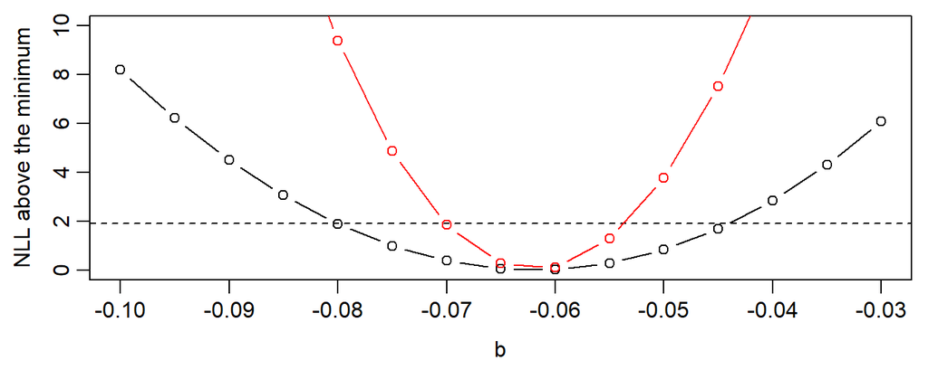

## Why the slice is narrower

The slice crosses 1.92 much closer to the best $b$, so its interval is less than half as wide.

It holds $a$ at one value. But $a$ and $b$ are strongly correlated (about −0.89): a curve that starts higher has to fall faster. The profile lets $a$ adjust at every $b$, so it finds a lower NLL there and accepts a wider range of $b$.

The slice is not wrong about the surface. It is answering a different question, “how plausible is this $b$ **if $a$ is known exactly**?”, and nobody knows $a$ exactly.

## `confint()`

```r
confint(m_occ)
```

```
        2.5 %      97.5 %
a  1.76994330  2.27537431
b -0.08018315 -0.04388737
```

```r
confint(m_occ, method = "quad")
```

```
        2.5 %     97.5 %
a  1.76513290  2.2702432
b -0.08003569 -0.0437609
```

## Back-transforming

```r
exp(confint(m_occ)["b", ])
```

```
    2.5 %    97.5 %
0.9229473 0.9570617
```

```r
1 - exp(confint(m_occ)["b", ])
```

```
     2.5 %     97.5 %
0.07705270 0.04293826
```

The odds of occupancy fall by between about 4.3% and 7.7% a year. Zero is not in the interval for $b$, so a flat line is ruled out.

## Development

```r
urban_nll2 <- function(params, y, u){
  mu <- params[1] * exp(params[2] * u)
  -sum(dnbinom(y, mu = mu, size = params[3], log = TRUE))
}
parnames(urban_nll2) <- c("mu0", "b", "size")

m_urban <- mle2(minuslogl = urban_nll2,
                start = c(mu0 = 12, b = -3, size = 1.4),
                data = list(y = counts$count, u = counts$frac_built),
                method = "L-BFGS-B",
                lower = c(mu0 = 0.1, b = -20, size = 0.05),
                upper = c(mu0 = 100, b = 20, size = 50))

confint(m_urban)
```

```
         2.5 %    97.5 %
mu0  11.511323 12.788783
b    -3.787275 -2.653440
size  1.360144  1.601922
```

```r
log(2) / abs(confint(m_urban)["b", ])
```

```
    2.5 %    97.5 %
0.1830200 0.2612259
```

Counts halve with every 18% to 26% of development. The steeper end of $b$ gives the shorter halving distance, so the two ends swap places.

## Additional practice: coverage

```r
interval_from_curve <- function(k, n, p_vec){
  nll <- -dbinom(k, size = n, prob = p_vec, log = TRUE)
  range(p_vec[nll <= min(nll) + 1.92])
}

set.seed(17)
p_grid <- seq(0.001, 0.999, by = 0.001)
lower <- numeric(100)
upper <- numeric(100)

for (i in 1:100) {
  k <- rbinom(1, size = 71, prob = 0.73)
  ci <- interval_from_curve(k, 71, p_grid)
  lower[i] <- ci[1]
  upper[i] <- ci[2]
}

mean(lower < 0.73 & upper > 0.73)
```

```
[1] 0.97
```

About 0.95, give or take a few, from 100 tries.

## Step 5: a rare species, with the shortcut

```r
set.seed(17)
lower <- numeric(1000)
upper <- numeric(1000)

for (i in 1:1000) {
  k <- rbinom(1, size = 71, prob = 0.03)
  p_hat <- k / 71
  se <- sqrt(p_hat * (1 - p_hat) / 71)
  lower[i] <- p_hat - 1.96 * se
  upper[i] <- p_hat + 1.96 * se
}

mean(lower < 0.03 & upper > 0.03)    # how often it catches the truth
```

```
[1] 0.862
```

```r
mean(upper <= 0.03)                  # missed by being entirely too low
```

```
[1] 0.136
```

```r
mean(lower < 0)                      # proposed a negative probability
```

```
[1] 0.706
```

## What step 5 shows

The shortcut is meant to catch the truth 95% of the time. With a rare species it falls well short, and its misses are lopsided: almost all of them sit entirely below the truth.

The worst case is **zero** sightings, which happens about one survey in nine here. Then $\hat{p} = 0$, the standard error is 0, and the “interval” is the single point 0: complete certainty, from no data.

The interval from the likelihood curve has neither problem. It fails least in exactly the situation where people most need it: when the species is rare.